# Predicting activity from wearable technology data

Haliburton

Saturday, June 20, 2015

```r
library(caret);library(lubridate)
library(RCurl);library(dplyr)
```

# Background

Using wearable devices, it is possible to collect a large amount of data about personal activity relatively inexpensively. 6 participants were asked to perform barbell lifts correctly and incorrectly in 5 different ways. The goal of this project is to use data from accelerometers on the belt, forearm, arm, and dumbell of the participants to predict the manner in which they did the exercise, (“classe” variable in the training set) using any variables in the data. More information is available from the website here: http://groupware.les.inf.puc-rio.br/har

# Read in the data

```r
data <- getURL("https://d396qusza40orc.cloudfront.net/predmachlearn/pml-training.csv",
               ssl.verifypeer=0L, followlocation=1L)
writeLines(data,'./data/pml-training.csv')
dd <- read.table("./data/pml-training.csv", sep=",",header=T, stringsAsFactors = FALSE)
```

## Cleaning, exploring and inspecting data

```r
cleanset <- dd
        #Find variables that have virtually zero variances and remove them
        #as they are unlikely to be good predictors
        nsv <- nearZeroVar(cleanset,saveMetrics = TRUE);length(nsv[nsv$nzv==TRUE,])
        zerovars <- nsv[nsv$nzv==TRUE,];zvars <- rownames(zerovars)
        #Subset the data to only use data that has likely predictors
        trainingss <- subset(cleanset, select = ! names(cleanset) %in% zvars)

        #Find and remove columns that have high ratio of NA to non-NA as they'd be unhelpful
        highNA <- colSums(is.na(trainingss));noNA <- colSums(!is.na(trainingss))
        mytest <- rbind(highNA,noNA)
        mmtest <- as.data.frame(t(mytest)) # swap the columns to rows for easy computation and subsetting
        mmtest$perc <- mmtest$highNA/(mmtest$noNA + mmtest$highNA)
        tooHigh <- mmtest[mmtest$perc>.9,] # Chose 90% as cutoff ratio to exclude
        highNADrops <- rownames(tooHigh)
trainingss <- subset(trainingss, select = ! names(trainingss) %in% highNADrops)
```

## Create training and testing sets.

```r
inTrain <- createDataPartition(y=trainingss$classe,p=0.6,list=FALSE)
training <- trainingss[inTrain,]
testing <- trainingss[-inTrain,]
```

# Principal component analysis

PCA needs numeric values only so for PCA investigation, drop all non-numeric values and the outcome variable from the training set.

Drop columns because those might affect predictions in unhelpful ways due to artificial ordering of the data for ‘X’ (which is a sequence number) and dates and timestamps related to the order in which each subject carried out the intentional exercise.

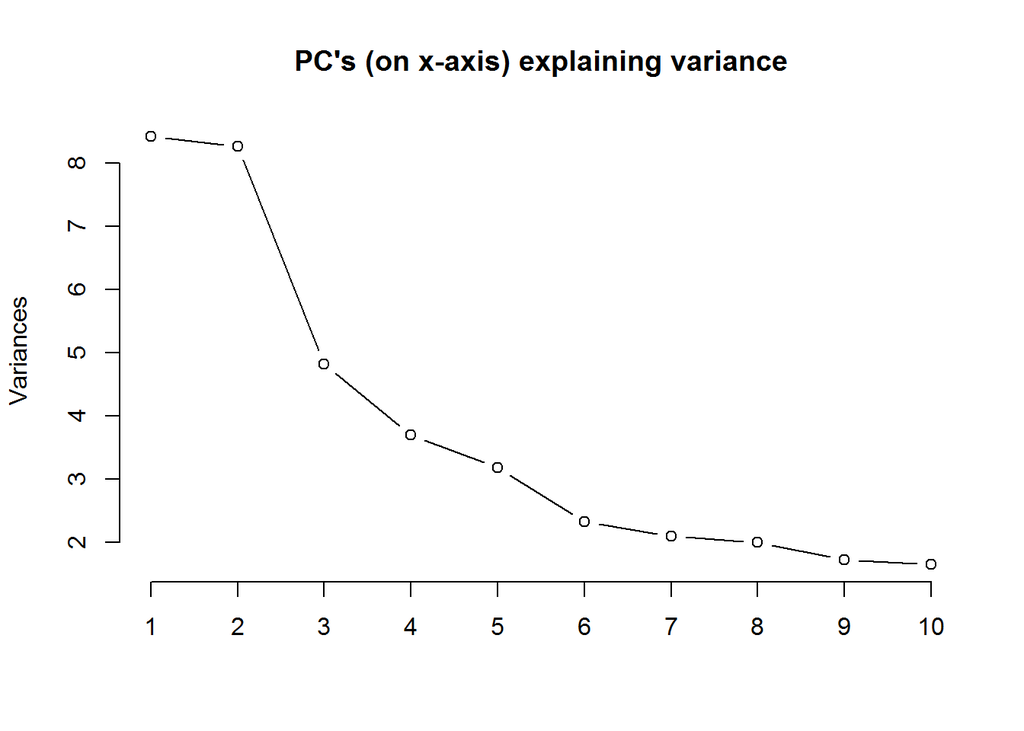

```r
        drops <- c("X","user_name","date", "raw_timestamp_part_1","raw_timestamp_part_2","cvtd_timestamp")
        mytrain2 <- subset(training, select = ! names(training) %in% drops);
        mytest2 <- subset(testing, select = ! names(testing) %in% drops)
        mytrain2$classe <- as.factor(mytrain2$classe);mytest2$classe <- as.factor(mytest2$classe)
mytrain2pca <- mytrain2[,-54]  #removing the outcome
m2pca <- prcomp(mytrain2pca, center = TRUE,scale. = TRUE)
plot(m2pca, main="PC's (on x-axis) explaining variance", type = "l") # plot how much each PC explains variance
```

The summary method describes the importance of the PCs. Here are just the first 4 PC’s for example.

```r
s <- summary(m2pca); s$importance[,1:4]
```

```
##                             PC1      PC2      PC3      PC4
## Standard deviation     2.901093 2.875295 2.195566 1.922122
## Proportion of Variance 0.158800 0.155990 0.090950 0.069710
## Cumulative Proportion  0.158800 0.314790 0.405740 0.475450
```

The first row describes the standard deviation associated with each PC. The second row shows the proportion of the variance in the data explained by each component. The third row describes the cumulative proportion of explained variance.

It shows that there aren’t just 2 or 3 principal components explaining 95% of the variance. We need a number of PC’s to explain the variance so the decision is to leave all of those variables in the model.

# Cross-validation

First model tested is a recursive partitioning model (rpart) with 10 folds for crossvalidation.

```r
tc <- trainControl("cv",10)
fitrpartcv<- train(classe ~ ., method="rpart", trControl=tc,data = mytrain2)
predrpartcv <- predict(fitrpartcv,mytest2)
cmrpartcv <- confusionMatrix(predrpartcv, mytest2$classe)
accuracyrpartcv <- cmrpartcv$overall[1]
oosrpartcv <- 1-accuracyrpartcv
cmrpartcv
```

```
## Confusion Matrix and Statistics
##
##           Reference
## Prediction    A    B    C    D    E
##          A 2009  626  652  561  202
##          B   42  505   40  232  181
##          C  172  387  676  493  424
##          D    0    0    0    0    0
##          E    9    0    0    0  635
##
## Overall Statistics
##
##                Accuracy : 0.4875
##                  95% CI : (0.4764, 0.4986)
##     No Information Rate : 0.2845
##     P-Value [Acc > NIR] : < 2.2e-16
##
##                   Kappa : 0.3306
##  Mcnemar's Test P-Value : NA
##
## Statistics by Class:
##
##                      Class: A Class: B Class: C Class: D Class: E
## Sensitivity            0.9001  0.33267  0.49415   0.0000  0.44036
## Specificity            0.6364  0.92178  0.77215   1.0000  0.99859
## Pos Pred Value         0.4960  0.50500  0.31413      NaN  0.98602
## Neg Pred Value         0.9413  0.85203  0.87847   0.8361  0.88795
## Prevalence             0.2845  0.19347  0.17436   0.1639  0.18379
## Detection Rate         0.2561  0.06436  0.08616   0.0000  0.08093
## Detection Prevalence   0.5162  0.12745  0.27428   0.0000  0.08208
## Balanced Accuracy      0.7683  0.62723  0.63315   0.5000  0.71948
```

Tried another rpart model with default bootstrap sampling using 25 repetitions.

```r
fitrpart<- train(classe ~ ., method="rpart", data = mytrain2)
predrpart <- predict(fitrpart,mytest2)
cmrpart <- confusionMatrix(predrpart, mytest2$classe)
accuracyrpart <- cmrpart$overall[1]
oosrpart <- 1-accuracyrpart
cmrpart
```

```
## Confusion Matrix and Statistics
##
##           Reference
## Prediction    A    B    C    D    E
##          A 2009  626  652  561  202
##          B   42  505   40  232  181
##          C  172  387  676  493  424
##          D    0    0    0    0    0
##          E    9    0    0    0  635
##
## Overall Statistics
##
##                Accuracy : 0.4875
##                  95% CI : (0.4764, 0.4986)
##     No Information Rate : 0.2845
##     P-Value [Acc > NIR] : < 2.2e-16
##
##                   Kappa : 0.3306
##  Mcnemar's Test P-Value : NA
##
## Statistics by Class:
##
##                      Class: A Class: B Class: C Class: D Class: E
## Sensitivity            0.9001  0.33267  0.49415   0.0000  0.44036
## Specificity            0.6364  0.92178  0.77215   1.0000  0.99859
## Pos Pred Value         0.4960  0.50500  0.31413      NaN  0.98602
## Neg Pred Value         0.9413  0.85203  0.87847   0.8361  0.88795
## Prevalence             0.2845  0.19347  0.17436   0.1639  0.18379
## Detection Rate         0.2561  0.06436  0.08616   0.0000  0.08093
## Detection Prevalence   0.5162  0.12745  0.27428   0.0000  0.08208
## Balanced Accuracy      0.7683  0.62723  0.63315   0.5000  0.71948
```

Looking at the table results and overall stats, the accuracy is still low: 0.4875096 . Out of sample error is 0.5124904 .

Second model tested is linear discriminant analysis

```r
fitlda <- train(classe ~ ., method="lda", data = mytrain2)
predlda<- predict(fitlda, mytest2)
cmlda <- confusionMatrix(predlda, mytest2$classe)
accuracylda <- cmlda$overall[1]
ooslda <- 1-accuracylda
cmlda
```

```
## Confusion Matrix and Statistics
##
##           Reference
## Prediction    A    B    C    D    E
##          A 1825  209  127   66   59
##          B   68  992  115   53  186
##          C  160  209  923  137  156
##          D  172   51  166  978  144
##          E    7   57   37   52  897
##
## Overall Statistics
##
##                Accuracy : 0.7157
##                  95% CI : (0.7055, 0.7256)
##     No Information Rate : 0.2845
##     P-Value [Acc > NIR] : < 2.2e-16
##
##                   Kappa : 0.6405
##  Mcnemar's Test P-Value : < 2.2e-16
##
## Statistics by Class:
##
##                      Class: A Class: B Class: C Class: D Class: E
## Sensitivity            0.8177   0.6535   0.6747   0.7605   0.6221
## Specificity            0.9179   0.9333   0.8978   0.9187   0.9761
## Pos Pred Value         0.7983   0.7016   0.5823   0.6473   0.8543
## Neg Pred Value         0.9268   0.9182   0.9289   0.9514   0.9198
## Prevalence             0.2845   0.1935   0.1744   0.1639   0.1838
## Detection Rate         0.2326   0.1264   0.1176   0.1246   0.1143
## Detection Prevalence   0.2914   0.1802   0.2020   0.1926   0.1338
## Balanced Accuracy      0.8678   0.7934   0.7863   0.8396   0.7991
```

Cross valiation: the model used default bootstrapping with 25 repetitions. Accuracy is improved: 0.7156513. Out of sample error 0.2843487 .

Third model tested is random forests

```r
fitrf <- train(classe ~ ., method="rf", data = mytrain2)
predrf <- predict(fitrf, mytest2)
cmrf <- confusionMatrix(predrf, mytest2$classe)
accuracyrf <- cmrf$overall[1]
oosrf <- 1-accuracyrf
cmrf
```

```
## Confusion Matrix and Statistics
##
##           Reference
## Prediction    A    B    C    D    E
##          A 2231    2    0    0    0
##          B    0 1513    2    0    0
##          C    0    2 1366   10    0
##          D    0    1    0 1276   10
##          E    1    0    0    0 1432
##
## Overall Statistics
##
##                Accuracy : 0.9964
##                  95% CI : (0.9948, 0.9976)
##     No Information Rate : 0.2845
##     P-Value [Acc > NIR] : < 2.2e-16
##
##                   Kappa : 0.9955
##  Mcnemar's Test P-Value : NA
##
## Statistics by Class:
##
##                      Class: A Class: B Class: C Class: D Class: E
## Sensitivity            0.9996   0.9967   0.9985   0.9922   0.9931
## Specificity            0.9996   0.9997   0.9981   0.9983   0.9998
## Pos Pred Value         0.9991   0.9987   0.9913   0.9915   0.9993
## Neg Pred Value         0.9998   0.9992   0.9997   0.9985   0.9984
## Prevalence             0.2845   0.1935   0.1744   0.1639   0.1838
## Detection Rate         0.2843   0.1928   0.1741   0.1626   0.1825
## Detection Prevalence   0.2846   0.1931   0.1756   0.1640   0.1826
## Balanced Accuracy      0.9996   0.9982   0.9983   0.9953   0.9965
```

Random forests model produced the best accuracy of all models. 0.9964313 . Out of sample error: 0.0035687 .

# Conclusion

Validate the data against testing set.

```r
URL <- "https://d396qusza40orc.cloudfront.net/predmachlearn/pml-testing.csv"
download.file(URL, destfile = "./data/pml-testing.csv")
test <- read.table("./data/pml-testing.csv", sep=",",header=T, stringsAsFactors = FALSE)
predrfreal <- predict(fitrf, test);answers <- as.character(predrfreal) #Create predictions on test problem_id's
```